# MEDICAL COST INSURANCE (PROJECT)

## SUMMARY STATISTICS

```python
import pandas as pd
import numpy as np

data = pd.read_csv(r"C:\Users\yasmi\OneDrive\Desktop\insurance.csv")
print('Head of the dataset : ')
data.head()
```

```
Head of the dataset :
```

|  | age | sex | bmi | children | smoker | region | charges |
| --- | --- | --- | --- | --- | --- | --- | --- |
| 0 | 19 | female | 27.900 | 0 | yes | southwest | 16884.92400 |
| 1 | 18 | male | 33.770 | 1 | no | southeast | 1725.55230 |
| 2 | 28 | male | 33.000 | 3 | no | southeast | 4449.46200 |
| 3 | 33 | male | 22.705 | 0 | no | northwest | 21984.47061 |
| 4 | 32 | male | 28.880 | 0 | no | northwest | 3866.85520 |

```python
print('Data Info : ')
print(data.info())

print('Describe Data : ')
print(data.describe())
```

```
Data Info :
<class 'pandas.core.frame.DataFrame'>
RangeIndex: 1338 entries, 0 to 1337
Data columns (total 7 columns):
 #   Column    Non-Null Count  Dtype
---  ------    --------------  -----
 0   age       1338 non-null   int64
 1   sex       1338 non-null   object
 2   bmi       1338 non-null   float64
 3   children  1338 non-null   int64
 4   smoker    1338 non-null   object
 5   region    1338 non-null   object
 6   charges   1338 non-null   float64
dtypes: float64(2), int64(2), object(3)
memory usage: 73.3+ KB
None
Describe Data :
               age          bmi     children       charges
count  1338.000000  1338.000000  1338.000000   1338.000000
mean     39.207025    30.663397     1.094918  13270.422265
std      14.049960     6.098187     1.205493  12110.011237
min      18.000000    15.960000     0.000000   1121.873900
25%      27.000000    26.296250     0.000000   4740.287150
50%      39.000000    30.400000     1.000000   9382.033000
75%      51.000000    34.693750     2.000000  16639.912515
max      64.000000    53.130000     5.000000  63770.428010
```

### CHECKING MISSING VALUES

```python
data.isna().sum()
```

```
age         0
sex         0
bmi         0
children    0
smoker      0
region      0
charges     0
dtype: int64
```

### ENCODING CATEGORICAL COLUMNS

```python
data_encoded = pd.get_dummies(data , drop_first = True)
print('Encoded Data columns : ')
data_encoded
```

```
Encoded Data columns :
```

|  | age | bmi | children | charges | sex_male | smoker_yes | region_northwest | region_southeast | region_southwest |
| --- | --- | --- | --- | --- | --- | --- | --- | --- | --- |
| 0 | 19 | 27.900 | 0 | 16884.92400 | False | True | False | False | True |
| 1 | 18 | 33.770 | 1 | 1725.55230 | True | False | False | True | False |
| 2 | 28 | 33.000 | 3 | 4449.46200 | True | False | False | True | False |
| 3 | 33 | 22.705 | 0 | 21984.47061 | True | False | True | False | False |
| 4 | 32 | 28.880 | 0 | 3866.85520 | True | False | True | False | False |
| ... | ... | ... | ... | ... | ... | ... | ... | ... | ... |
| 1333 | 50 | 30.970 | 3 | 10600.54830 | True | False | True | False | False |
| 1334 | 18 | 31.920 | 0 | 2205.98080 | False | False | False | False | False |
| 1335 | 18 | 36.850 | 0 | 1629.83350 | False | False | False | True | False |
| 1336 | 21 | 25.800 | 0 | 2007.94500 | False | False | False | False | True |
| 1337 | 61 | 29.070 | 0 | 29141.36030 | False | True | True | False | False |

1338 rows × 9 columns

```python
print('\n Summary Statistics of Encoded data : ')
data_encoded.describe()
```

```
 Summary Statistics of Encoded data :
```

|  | age | bmi | children | charges |
| --- | --- | --- | --- | --- |
| count | 1338.000000 | 1338.000000 | 1338.000000 | 1338.000000 |
| mean | 39.207025 | 30.663397 | 1.094918 | 13270.422265 |
| std | 14.049960 | 6.098187 | 1.205493 | 12110.011237 |
| min | 18.000000 | 15.960000 | 0.000000 | 1121.873900 |
| 25% | 27.000000 | 26.296250 | 0.000000 | 4740.287150 |
| 50% | 39.000000 | 30.400000 | 1.000000 | 9382.033000 |
| 75% | 51.000000 | 34.693750 | 2.000000 | 16639.912515 |
| max | 64.000000 | 53.130000 | 5.000000 | 63770.428010 |

### CORRELATION ANALYSIS

```python
data_corr = data_encoded.corr()
data_corr
```

|  | age | bmi | children | charges | sex_male | smoker_yes | region_northwest | region_southeast | region_southwest |
| --- | --- | --- | --- | --- | --- | --- | --- | --- | --- |
| age | 1.000000 | 0.109272 | 0.042469 | 0.299008 | -0.020856 | -0.025019 | -0.000407 | -0.011642 | 0.010016 |
| bmi | 0.109272 | 1.000000 | 0.012759 | 0.198341 | 0.046371 | 0.003750 | -0.135996 | 0.270025 | -0.006205 |
| children | 0.042469 | 0.012759 | 1.000000 | 0.067998 | 0.017163 | 0.007673 | 0.024806 | -0.023066 | 0.021914 |
| charges | 0.299008 | 0.198341 | 0.067998 | 1.000000 | 0.057292 | 0.787251 | -0.039905 | 0.073982 | -0.043210 |
| sex_male | -0.020856 | 0.046371 | 0.017163 | 0.057292 | 1.000000 | 0.076185 | -0.011156 | 0.017117 | -0.004184 |
| smoker_yes | -0.025019 | 0.003750 | 0.007673 | 0.787251 | 0.076185 | 1.000000 | -0.036945 | 0.068498 | -0.036945 |
| region_northwest | -0.000407 | -0.135996 | 0.024806 | -0.039905 | -0.011156 | -0.036945 | 1.000000 | -0.346265 | -0.320829 |
| region_southeast | -0.011642 | 0.270025 | -0.023066 | 0.073982 | 0.017117 | 0.068498 | -0.346265 | 1.000000 | -0.346265 |
| region_southwest | 0.010016 | -0.006205 | 0.021914 | -0.043210 | -0.004184 | -0.036945 | -0.320829 | -0.346265 | 1.000000 |

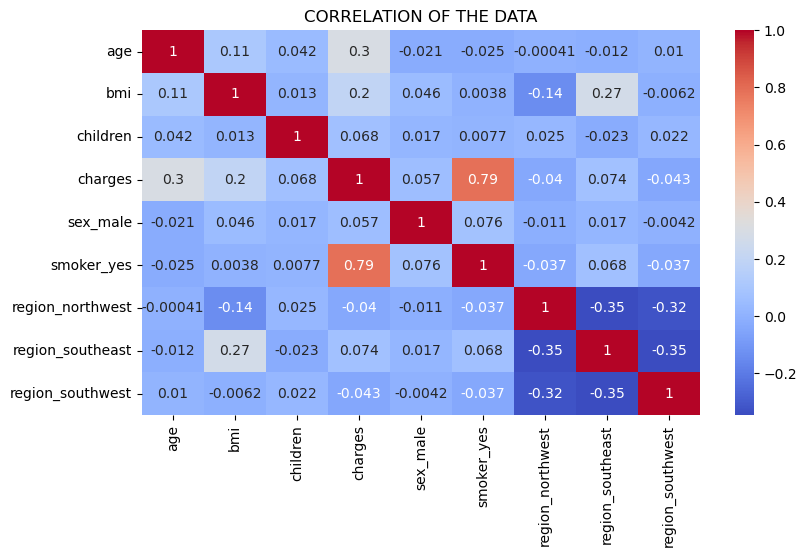

```python
import seaborn as sns
import matplotlib.pyplot as plt
plt.figure(figsize = (9 , 5))
sns.heatmap(data_corr , annot = True , cmap = 'coolwarm')
plt.title('CORRELATION OF THE DATA')
plt.show()
```

### The correlation heatmap shows how each feature is related to the insurance charges.

The strongest positive correlation is between smoker status and charges (0.79), indicating that smokers pay significantly higher medical costs. Age also has a moderate positive correlation (0.30), meaning older individuals tend to have higher charges. BMI shows a weak positive correlation (0.20), while the number of children and gender show almost no relationship with insurance costs. The regional dummy variables show small negative correlations with each other due to mutual exclusivity. Overall, smoking, age, and BMI are the most influential factors, as confirmed by the correlation matrix.

### HYPOTHESIS TESTING

#### T-TEST OF INDEPENDENCE (SMOKERS VS NON-SMOKERS)

```python
data.head()
```

|  | age | sex | bmi | children | smoker | region | charges |
| --- | --- | --- | --- | --- | --- | --- | --- |
| 0 | 19 | female | 27.900 | 0 | yes | southwest | 16884.92400 |
| 1 | 18 | male | 33.770 | 1 | no | southeast | 1725.55230 |
| 2 | 28 | male | 33.000 | 3 | no | southeast | 4449.46200 |
| 3 | 33 | male | 22.705 | 0 | no | northwest | 21984.47061 |
| 4 | 32 | male | 28.880 | 0 | no | northwest | 3866.85520 |

```python
from scipy import stats

smokers = data[data['smoker'] == 'yes']['charges']
non_smokers = data[data['smoker'] == 'no']['charges']

t_stat , p_value = stats.ttest_ind(smokers , non_smokers)
print('-----T-Test on Smokers VS Non-Smokers------')
print('\nT-Stat : ',t_stat)
print('P-value : ',p_value)
```

```
-----T-Test on Smokers VS Non-Smokers------

T-Stat :  46.66492117272371
P-value :  8.271435842179102e-283
```

### A two-sample independent t-test was performed to compare the insurance charges of smokers and non-smokers.

The results showed a very high t-statistic (46.66) and an extremely small p-value (8.27 × 10⁻²⁸³), which is far below the 0.05 significance level. This indicates that the difference in average medical charges between smokers and non-smokers is statistically significant. Smokers pay much higher insurance charges than non-smokers, and this difference is not due to random chance. These findings strongly support the insights obtained from the boxplot, correlation heatmap, and regression model, confirming that smoking is the most influential factor in determining insurance costs

```python
male = data[data['sex'] == 'male']['charges']
female = data[data['sex'] == 'female']['charges']

t_stat , p_value = stats.ttest_ind(male , female)
print('-----T-Test on Male VS Female------')
print('\nT-Stat : ',t_stat)
print('P-value : ',p_value)
```

```
-----T-Test on Male VS Female------

T-Stat :  2.097546590051688
P-value :  0.03613272100592976
```

### A two-sample independent t-test was conducted to determine whether there is a significant difference in insurance charges between male and female customers.

The test produced a t-statistic of 2.09 and a p-value of 0.036. Since the p-value is slightly below the 0.05 significance level, the result indicates a small but statistically significant difference between the average charges of males and females. However, this difference is much smaller compared to the smoker vs non-smoker comparison, suggesting that gender has only a minor influence on medical insurance charges. Overall, sex is not a major determining factor in predicting charges, which aligns with the low correlation values observed earlier.

## ANOVA

```python
R1 = data[data['region'] == 'southwest']['charges']
R2 = data[data['region'] == 'southeast']['charges']
R3 = data[data['region'] == 'northwest']['charges']
R4 = data[data['region'] == 'northeast']['charges']

F_stat , p_value = stats.f_oneway(R1 , R2 , R3 , R4)
print('---------ANOVA TEST ON REGIONS----------')
print('\nF-Stat : ',F_stat)
print('P-value : ',p_value)
```

```
---------ANOVA TEST ON REGIONS----------

F-Stat :  2.96962669358912
P-value :  0.0308933560705201
```

### A one-way ANOVA test was performed to examine whether insurance charges differ significantly across the four regions: southwest, southeast, northwest, and northeast.

The test produced an F-statistic of 2.96 and a p-value of 0.0308. Since the p-value is slightly below the 0.05 significance threshold, the result indicates a small but statistically significant difference in average charges between regions. However, the effect size is very small, meaning region does not play a major role in determining insurance charges. This aligns with the earlier correlation and regression results, which showed that regional differences have minimal influence compared to strong predictors like smoking, age, and BMI.

### EXPLORATORY DATA ANALYSIS (VISUALIZATION)

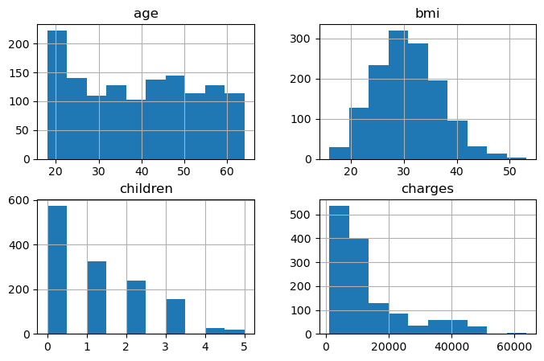

```python
data.hist(figsize = (8 , 5))
plt.show()
```

#### The histograms reveal the distribution patterns of the dataset’s numerical variables.

Age is mostly concentrated between 20 and 60 years. BMI follows a normal distribution centered around 30. The number of children is heavily skewed, with most individuals having no children. Insurance charges show a strong right skew, meaning a small group of customers incur very high costs. These patterns help us understand the characteristics of the population and guide further statistical analysis.

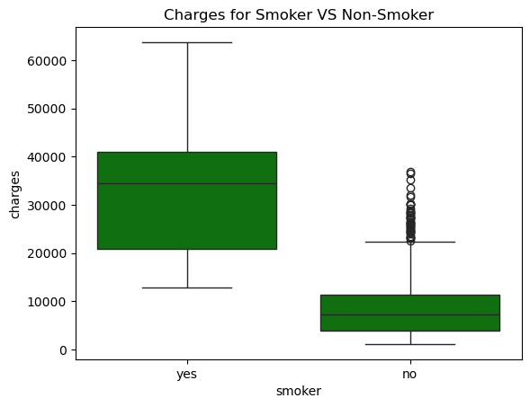

```python
sns.boxplot(x = 'smoker' , y = 'charges' , data = data , color = 'green')
plt.title('Charges for Smoker VS Non-Smoker')
plt.show()
```

### The boxplot clearly shows the significant difference in insurance charges between smokers and non-smokers.

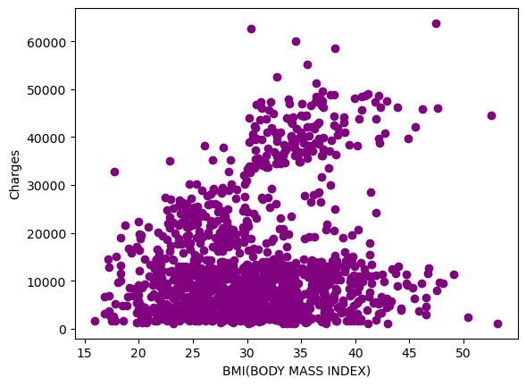

```python
plt.scatter(data['bmi'] , data['charges'] , color = 'purple')
plt.xlabel('BMI(BODY MASS INDEX)')
plt.ylabel('Charges')
plt.show()
```

### The scatter plot shows the relationship between BMI and insurance charges.

Overall, charges tend to increase as BMI increases, indicating a weak positive correlation. Individuals with higher BMI values (above 30) generally incur higher medical expenses. However, the points are widely spread, showing that BMI alone does not strongly determine the insurance cost. The presence of extremely high charges at higher BMI levels suggests that BMI combined with other factors, especially smoking, leads to higher healthcare expenses. This aligns with the correlation analysis, where BMI showed a weak positive correlation with charges.

### LINEAR ALGEBRA (CENTERING + COVARIENCE)

```python
X = data_encoded.drop('charges', axis=1).to_numpy()

print("X shape:", X.shape)

mean_X = np.mean(X, axis=0)
print("Mean shape:", mean_X.shape)

X_centered = X - mean_X
print("X_centered shape:", X_centered.shape)

X_centered = X_centered.astype(float)
cov_matrix = np.cov(X_centered, rowvar=False)
print("\nCovariance matrix:")
cov_matrix
```

```
X shape: (1338, 8)
Mean shape: (8,)
X_centered shape: (1338, 8)

Covariance matrix:
```

```
array([[ 1.97401387e+02,  9.36233663e+00,  7.19302747e-01,
        -1.46558847e-01, -1.41903487e-01, -2.45569080e-03,
        -7.28176886e-02,  6.03715343e-02],
       [ 9.36233663e+00,  3.71878836e+01,  9.37947634e-02,
         1.41435095e-01,  9.23280485e-03, -3.55777098e-01,
         7.33061737e-01, -1.62333432e-02],
       [ 7.19302747e-01,  9.37947634e-02,  1.45321275e+00,
         1.03482240e-02,  3.73412577e-03,  1.28285108e-02,
        -1.23785151e-02,  1.13326245e-02],
       [-1.46558847e-01,  1.41435095e-01,  1.03482240e-02,
         2.50159595e-01,  1.53825858e-02, -2.39364170e-03,
         3.81126789e-03, -8.97755388e-04],
       [-1.41903487e-01,  9.23280485e-03,  3.73412577e-03,
         1.53825858e-02,  1.62968876e-01, -6.39832389e-03,
         1.23103170e-02, -6.39832389e-03],
       [-2.45569080e-03, -3.55777098e-01,  1.28285108e-02,
        -2.39364170e-03, -6.39832389e-03,  1.84037060e-01,
        -6.61298022e-02, -5.90444663e-02],
       [-7.28176886e-02,  7.33061737e-01, -1.23785151e-02,
         3.81126789e-03,  1.23103170e-02, -6.61298022e-02,
         1.98185930e-01, -6.61298022e-02],
       [ 6.03715343e-02, -1.62333432e-02,  1.13326245e-02,
        -8.97755388e-04, -6.39832389e-03, -5.90444663e-02,
        -6.61298022e-02,  1.84037060e-01]])
```

I calculated the covariance matrix to understand how each numerical feature varies and how they relate to each other. From the covariance matrix, I observed that age and BMI have the highest variances, meaning these features spread out the most in the dataset. The off-diagonal values showed that most features have only weak relationships with each other, which means each variable contributes independently to the dataset.

### PCA (PRINCIPAL COMPONENT ANALYSIS)

```python
#Eigen decomposition
eigen_value , eigen_vec = np.linalg.eig(cov_matrix)

sorted_idx = np.argsort(eigen_value)[::-1]
sorted_eigval = eigen_value[sorted_idx]
sorted_eigvec = eigen_vec[:, sorted_idx]
```

##### Each principal component corresponds to one eigenvalue–eigenvector pair.

The largest eigenvalue represents the direction of maximum variance and its eigenvector becomes the first principal component (PC1). After sorting, the first column of the sorted eigenvector matrix corresponds to the largest eigenvalue, the second column corresponds to the second-largest eigenvalue, and so on. the largest variances occurred in ‘age’ and ‘BMI’, indicating that these variables have the widest spread among customers. Features such as children, smoker, sex, and region have relatively smaller variances because they are either discrete or binary dummy variables.

PC1 = eigenvector of largest eigenvalue

PC2 = eigenvector of second largest eigenvalue

PC3 = eigenvector of third largest eigenvalue

```python
for i , ev in enumerate(sorted_eigval):
    print(f'PC{i+1} : ')
    print('Eigen value : ',ev)
    print('Eigen vector : ',sorted_eigvec[: , i])
    print()
```

```
PC1 :
Eigen value :  197.94952083447853
Eigen vector :  [ 9.98301117e-01  5.81394679e-02  3.68214457e-03 -6.98334792e-04
 -7.13525069e-04 -1.16756408e-04 -1.52430440e-04  3.00300466e-04]

PC2 :
Eigen value :  36.661687388857644
Eigen vector :  [-5.81247417e-02  9.98047344e-01  1.46172331e-03  4.11411271e-03
  4.88958587e-04 -9.76588548e-03  2.01996329e-02 -5.60895719e-04]

PC3 :
Eigen value :  1.4509750780432982
Eigen vector :  [ 0.00360245  0.00137121 -0.99978644 -0.00887058 -0.00318512 -0.01066677
  0.01144444 -0.00886676]

PC4 :
Eigen value :  0.25504156355614765
Eigen vector :  [-0.00166748  0.01410705 -0.0028687  -0.73951594 -0.21923202  0.09744501
 -0.48754601  0.39704765]

PC5 :
Eigen value :  0.24809950343600176
Eigen vector :  [-1.70655423e-04  7.06472981e-03 -1.56263934e-02  6.32081169e-01
  4.50298492e-03 -8.55366036e-02 -5.02422679e-01  5.83450029e-01]

PC6 :
Eigen value :  0.23869804752315696
Eigen vector :  [-6.00896632e-04  1.49345866e-02 -1.08268125e-02  1.68090267e-01
 -6.15438679e-02  8.07979230e-01 -3.92107536e-01 -4.01296195e-01]

PC7 :
Eigen value :  0.15786871015024115
Eigen vector :  [-3.58919874e-04 -3.65001351e-03  4.51325938e-03  1.58841683e-01
 -9.73709837e-01 -7.17539560e-02  1.33855768e-01 -5.96544678e-02]

PC8 :
Eigen value :  0.059980407073468724
Eigen vector :  [ 3.42040676e-04 -5.84274762e-03 -4.62243460e-03  2.90791908e-03
  2.76727427e-03  5.70087472e-01  5.81090035e-01  5.80743412e-01]
```

#### Eigenvalues tell how much variance each component explains.

Eigenvectors show the direction of that component. We sort eigenvalues and reorder eigenvectors the same way, so the first eigenvector corresponds to the largest eigenvalue.

PC1 is dominated by age. Age is the feature with the highest variance and explains the largest part of the data’s variability.

PC2 captures BMI variation. BMI is the second most spread-out feature in the dataset.

PC3 is dominated by the ‘children’ feature. It explains a very small portion of total variance.

```python
explained_varience = sorted_eigval / np.sum(sorted_eigval)
print('Explained Varience Ratio : ')
explained_varience
```

```
Explained Varience Ratio :
```

```
array([8.35152974e-01, 1.54676390e-01, 6.12169277e-03, 1.07602544e-03,
       1.04673675e-03, 1.00707182e-03, 6.66051235e-04, 2.53058533e-04])
```

The explained variance ratio tells how much information each principal component captures. It is computed by dividing each eigenvalue by the sum of all eigenvalues. This helps us understand which components are most important for describing the dataset.

#### In my dataset, PC1 explains 83.5% of the total variance, and PC2 explains 15.47%.

Together, the first two principal components capture almost 99% of the variation. This means the dataset can be reduced from 8 dimensions to just 2 dimensions with almost no loss of information.

```python
W2 = sorted_eigvec[: , :2]
X_pca = X_centered @ W2

print('Original Shape : ',X.shape)
print('Shape after PCA : ',X_pca.shape)
```

```
Original Shape :  (1338, 8)
Shape after PCA :  (1338, 2)
```

#### My original dataset had 1338 samples with 8 features.

After computing the top 2 principal components, I multiplied the 1338×8 centered matrix with the 8×2 eigenvector matrix. This gives a 1338×2 matrix, meaning each sample is now represented by just 2 PCA features instead of 8.

### PCA VISUALIZATION

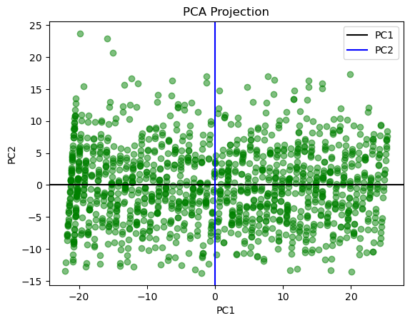

```python
plt.scatter(X_pca[:,0], X_pca[:,1] , alpha = 0.5 , color = 'green')
# Draw PC1 line (horizontal)
plt.axhline(0, color='black', linestyle='-', label='PC1')

# Draw PC2 line (vertical)
plt.axvline(0, color='blue', linestyle='-', label='PC2')

plt.xlabel("PC1")
plt.ylabel("PC2")
plt.title("PCA Projection")
plt.legend()
plt.show()
```

### LINEAR REGRESSION

```python
from sklearn.model_selection import train_test_split
from sklearn.linear_model import LinearRegression
from sklearn.metrics import r2_score , mean_squared_error

X_full = data_encoded.drop('charges' , axis = 1)
y = data_encoded['charges']

X_train , X_test , y_train , y_test = train_test_split(X_full , y , test_size = 0.2 , random_state = 42)

model = LinearRegression()
model.fit(X_train , y_train)
y_pred = model.predict(X_test)

print('-------------LINEAR REGRESSION-------------------')
print('\nR2 Score : ',r2_score(y_test , y_pred))    # measure how well the model is performing
print('\nMean-Squared-Error : ',mean_squared_error(y_test , y_pred))    # tells how far is the predictions from the real values

print('\nCo-efficient : ')
for col , coeff in zip(X_full.columns , model.coef_):
    print(f'\n{col} : {coeff} ')
```

```
-------------LINEAR REGRESSION-------------------

R2 Score :  0.7835929767120724

Mean-Squared-Error :  33596915.851361446

Co-efficient :

age : 256.9757058311941

bmi : 337.0925519487795

children : 425.2787835242921

sex_male : -18.59169164103678

smoker_yes : 23651.128855761228

region_northwest : -370.67732622778215

region_southeast : -657.8642965646497

region_southwest : -809.7993541824801
```